# Nuclear Counts Analysis - Part 1

HS Computational Biology

5/29/2018

```r
library(dplyr)
```

```r
library(ggplot2)
library()
```

First, open a terminal (command+spacebar and type terminal) and navigate to your folder with our git repository with `cd`. Remember, you can use tab for auto-completion and `cd ../` will take you up one level in the file tree.

To verify that we are in the correct location, we can use the command `pwd` (print working directory). If you are on a Mac, the output should look something like `/Users/justin/Documents/hsds`.

Next, download this file from Box and place it in `Week2/data`.

```bash
https://hemoshear.app.box.com/file/294498639388
```

We can use the `ls` command to see if our file is there for sure.

```bash
ls data
```

```
## PAH0552-NucCounts.txt
```

Once we have confirmed our data is in the right place, we can start our HemoShear RStudio Docker container. We will expose `Week2/data` on our computer to `/data` inside of the container. The `$YOURUSERNAME` bit will need to be changed to your own username. We will use `$` to denote variables in our command-line code.

```bash
docker run -d -p 8787:8787 -v /Users/$YOURUSERNAME/Documents/hsds/Week2/data:/home/rstudio/data hs-rstudio
```

Navigate to `localhost:8787` in your browser and also open up the raw data file in Excel.

```
ATF 1.0
5   5
Calculation applied: None
"Name [Measurement Set Info]=Transfluor"
"Name [Plate Info]=PAH0552-DAPI-Plate01_IMAGEXPRESS_116273"
"Description [Plate Info]=PAH0552-DAPI-Plate01"
"Date Created [Plate Info]=05/25/18"
"Settings Name [Measurement Set Info]=RNO Nuclear Count"
"Plate ID"  "Well Name" "Site ID"   "MEASUREMENT SET ID"    "Nuclear Count (Transfluor)"
116273  "B01"   1   79646   9735.0
116273  "B01"   2   79646   7693.0
116273  "B02"   1   79646   10951.0
116273  "B02"   2   79646   11065.0
116273  "B03"   1   79646   11469.0
116273  "B03"   2   79646   12487.0
...
```

```r
nuc_counts <- read.delim('data/PAH0552-NucCounts.txt')
```

We notice that the first 8 lines consist of metadata. We do not need that information for now, so we can open up the help page for `read.delim` with `?read.delim`. If we read closely, we can see that there is a `skip` argument that allows us to start reading the table at a different line than the first one.

```r
nuc_counts <- read.delim('data/PAH0552-NucCounts.txt', skip = 8, nrows=72-9)
```

Let’s change the names of the columns so that they are easier to read.

```r
colnames(nuc_counts)
```

```
## [1] "Plate.ID"                   "Well.Name"
## [3] "Site.ID"                    "MEASUREMENT.SET.ID"
## [5] "Nuclear.Count..Transfluor."
```

```r
colnames(nuc_counts) <- c('plate', 'well', 'site',
                         'measurement_set_id', 'nuc_count')
```

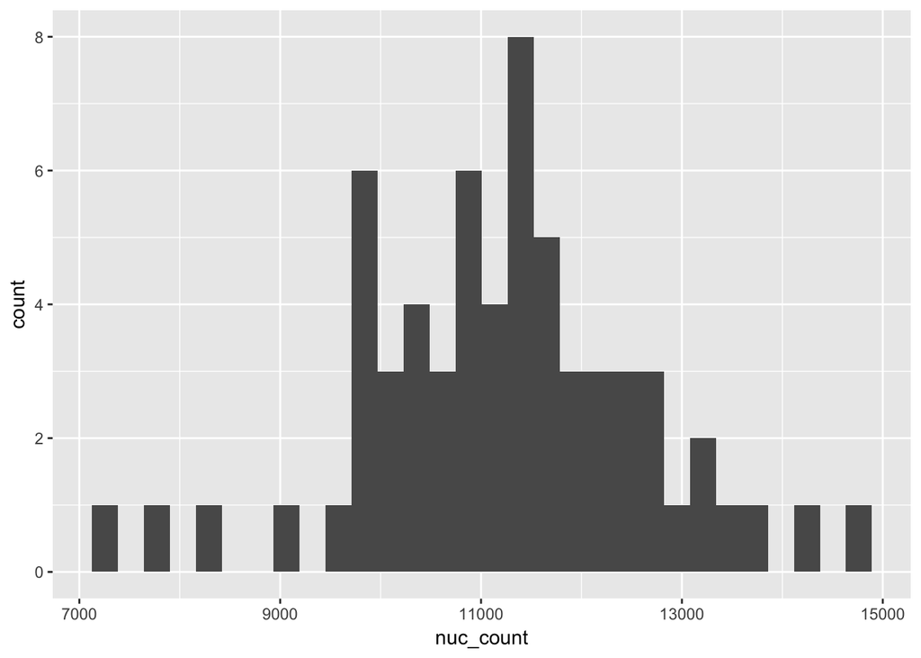

```r
ggplot(nuc_counts, aes(x=nuc_count)) +
  geom_histogram()
```

```r
# :readMolDev('data/PAH0552-NucCounts.txt')
```

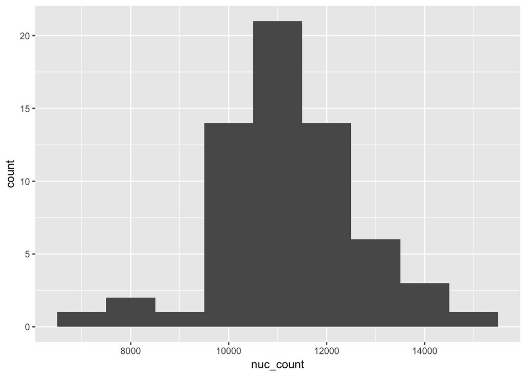

```r
ggplot(nuc_counts, aes(x=nuc_count)) +
  geom_histogram(binwidth=1000)
```

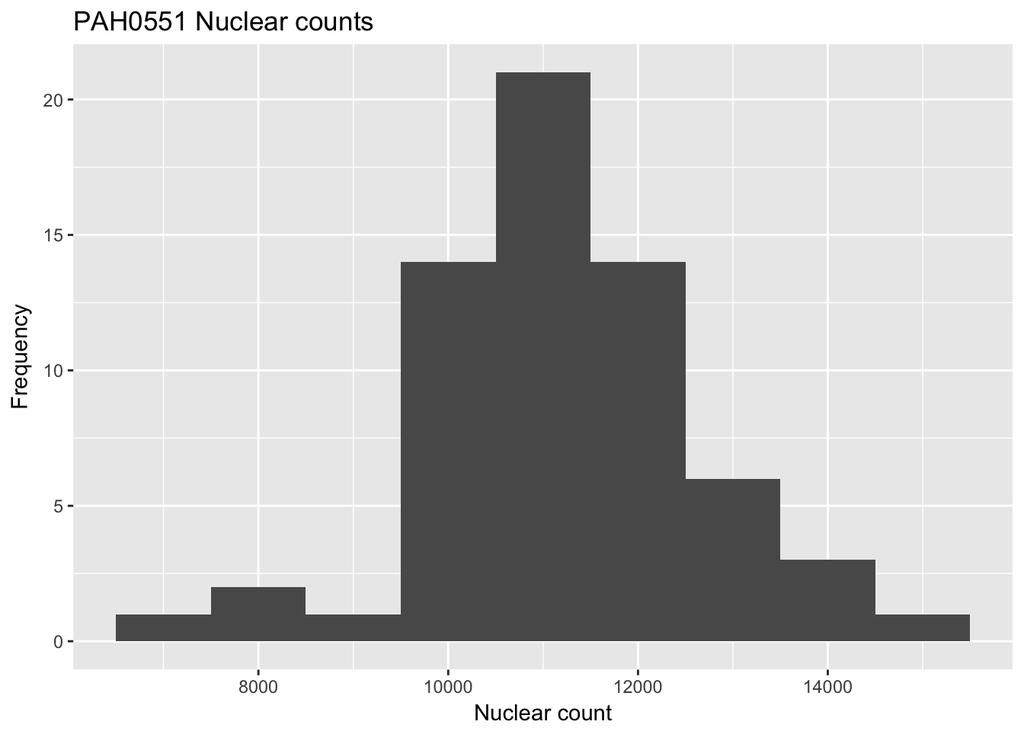

```r
ggplot(nuc_counts, aes(x=nuc_count)) +
  geom_histogram(binwidth=1000) +
  labs(x='Nuclear count', y='Frequency',
       title = 'PAH0551 Nuclear counts')
```

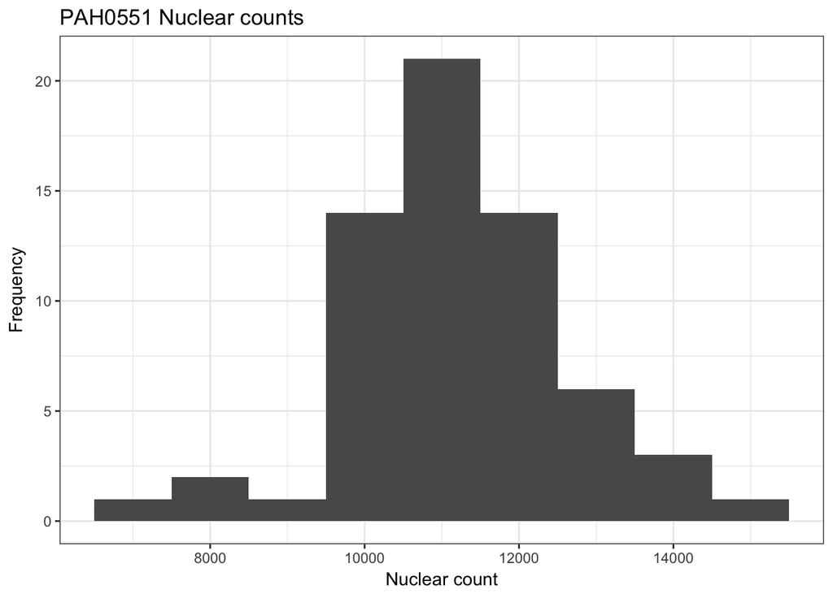

```r
ggplot(nuc_counts, aes(x=nuc_count)) +
  geom_histogram(binwidth=1000) +
  labs(x='Nuclear count', y='Frequency',
       title = 'PAH0551 Nuclear counts') +
  theme_bw()
```